# Introducción a R

Ejercicios clase 3 Resuelto

## TAREA CLASE 3

```r
library(tidyverse)
library(openxlsx)
library(ggplot2)
library(lubridate)
library(plotly)
options(scipen=999) # para quitar la notación científica
```

## 1-Cargar la base de vacunación de CABA.

```r
base_caba <- read.csv('https://raw.githubusercontent.com/pachedi/INTRO_R_CS/main/vacunas_caba.csv', encoding = 'UTF-8', fill = TRUE) %>%
  select(-(1))

base_caba <- base_caba %>%
  mutate(FECHA_ADMINISTRACION = ymd(FECHA_ADMINISTRACION)) %>% # cambiamos clase fecha
  select(-(8)) # eliminamos la columna que tiene el índice

head(base_caba)
```

```
##   FECHA_ADMINISTRACION GRUPO_ETARIO GENERO  VACUNA     TIPO_EFECTOR DOSIS_1
## 1           2021-02-11      51 a 60      M Sputnik Público nacional       1
## 2           2021-02-11      61 a 70      F Sputnik          Privado      20
## 3           2021-02-11      61 a 70      F Sputnik          Público      39
## 4           2021-02-11      61 a 70      F Sputnik Público nacional       2
## 5           2021-02-11      61 a 70      M Sputnik          Privado      24
## 6           2021-02-11      61 a 70      M Sputnik          Público      28
##   DOSIS_2 DOSIS_3
## 1       4       0
## 2       0       0
## 3       1       0
## 4       1       0
## 5       0       0
## 6       3       0
```

## 2- Crear una columna llamada “total_vacunas” que sea la suma de las 3 dosis en cada línea

```r
base_caba <- base_caba %>%
  mutate(total_vacunas = DOSIS_1+DOSIS_2+DOSIS_3)

base_caba[is.na(base_caba)] <- 0  # reemplazamos los valores faltantes por 0

head(base_caba)
```

```
##   FECHA_ADMINISTRACION GRUPO_ETARIO GENERO  VACUNA     TIPO_EFECTOR DOSIS_1
## 1           2021-02-11      51 a 60      M Sputnik Público nacional       1
## 2           2021-02-11      61 a 70      F Sputnik          Privado      20
## 3           2021-02-11      61 a 70      F Sputnik          Público      39
## 4           2021-02-11      61 a 70      F Sputnik Público nacional       2
## 5           2021-02-11      61 a 70      M Sputnik          Privado      24
## 6           2021-02-11      61 a 70      M Sputnik          Público      28
##   DOSIS_2 DOSIS_3 total_vacunas
## 1       4       0             5
## 2       0       0            20
## 3       1       0            40
## 4       1       0             3
## 5       0       0            24
## 6       3       0            31
```

## 3-Crear una nueva tabla con una variable resumen que indique la cantidad total de vacunas por grupo etario

```r
edades <- base_caba %>%
  group_by(GRUPO_ETARIO,GENERO) %>%
  summarise(Total = sum(total_vacunas))
head(edades)
```

```
## # A tibble: 6 × 3
## # Groups:   GRUPO_ETARIO [2]
##   GRUPO_ETARIO GENERO  Total
##   <chr>        <chr>   <dbl>
## 1 30 o menos   F      973472
## 2 30 o menos   M      927597
## 3 30 o menos   N           9
## 4 31 a 40      F      591042
## 5 31 a 40      M      535453
## 6 31 a 40      N           3
```

## 4- Crear un gráfico de barras por grupo etario dividido por género que exprese la cantidad de vacunas aplicadas:

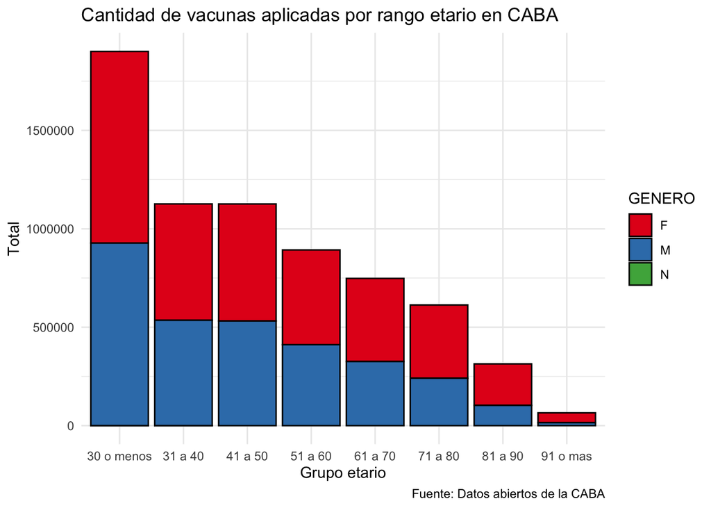

```r
ggplot(edades)+
  aes(x = GRUPO_ETARIO, y = Total, fill = GENERO)+
  geom_col( color = 'black')+
  labs(title = 'Cantidad de vacunas aplicadas por rango etario en CABA',
       x= 'Grupo etario',
       caption = 'Fuente: Datos abiertos de la CABA')+
  theme_minimal()+
  scale_fill_brewer(palette = "Set1")
```

## 5-Crear un gráfico de barras que agrupe por tipo de vacuna y tipo de dosis.

Agrupamos por vacuna y sumamos diferenciando por dosis.

```r
vacunas <- base_caba %>%
  group_by(VACUNA) %>%
  summarise(dosis1 = sum(DOSIS_1),
            dosis2 = sum(DOSIS_2),
            dosis3 = sum(DOSIS_3, na.rm = TRUE)) # na.rm sirve para quitar los valores NA (not available)

vacunas$VACUNA[5] = 'CANSINO' # reemplazamos el nombre de la vacuna por uno más corto
vacunas$VACUNA[6] = 'PFIZER'  # idem

vacunas <- vacunas %>%
  pivot_longer(., cols = 2:4, names_to = 'Dosis', values_to = 'Cantidad') # Pasamos las columnas de dosis como filas para poder graficar subdividiente

head(vacunas)
```

```
## # A tibble: 6 × 3
##   VACUNA      Dosis  Cantidad
##   <chr>       <chr>     <dbl>
## 1 AstraZeneca dosis1   747441
## 2 AstraZeneca dosis2   712484
## 3 AstraZeneca dosis3   532479
## 4 Moderna     dosis1    19179
## 5 Moderna     dosis2   249208
## 6 Moderna     dosis3   221416
```

Graficamos:

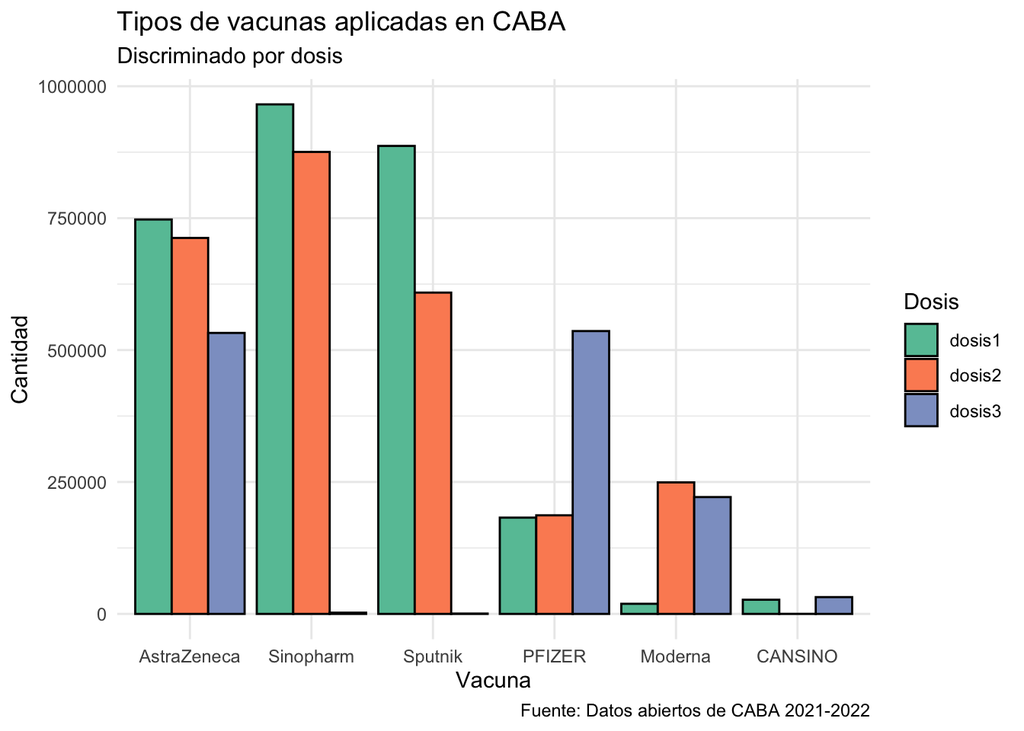

```r
ggplot(data = vacunas, aes(x= reorder(VACUNA, -Cantidad), y= Cantidad, fill= Dosis))+
  geom_col(position = position_dodge(), color = 'black')+
  labs(title = 'Tipos de vacunas aplicadas en CABA',
       subtitle = 'Discriminado por dosis',
       caption = 'Fuente: Datos abiertos de CABA 2021-2022',
       x = 'Vacuna')+
  theme_minimal()+
  scale_fill_brewer(palette = "Set2")
```

## 6- Crear un gráfico de línea que muestre la cantidad de vacunas aplicadas por día y por género con etiqueta mensual.

pista: agrupar por día y genero. De la base agrupada filtrar por genero.

```r
por_dia <- base_caba %>%
  group_by(FECHA_ADMINISTRACION, GENERO) %>%
  summarise(total_vacunas = sum(total_vacunas))
```

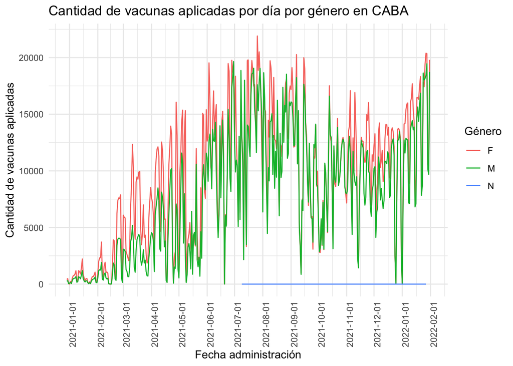

```r
ggplot(por_dia, aes(x = FECHA_ADMINISTRACION, y = total_vacunas))+
  geom_line(data = por_dia, aes(col = GENERO))+
  scale_x_date(date_breaks = '1 month')+
  theme_minimal()+
  theme(axis.text.x = element_text(angle = 90))+
  labs(title = 'Cantidad de vacunas aplicadas por día por género en CABA',
       x = 'Fecha administración', y='Cantidad de vacunas aplicadas',
       col = 'Género')
```

## 7-Realizar un gráfico de la cantidad de vacunas aplicadas por día por marca (pfizer, moderna, etc..)

Pista: utilizar la función facet_wrap() para crear los gráficos por marca.

```r
tipo_vacuna <- base_caba %>%
  group_by(FECHA_ADMINISTRACION, VACUNA) %>%
  summarise(total_vacunas = sum(total_vacunas))
```

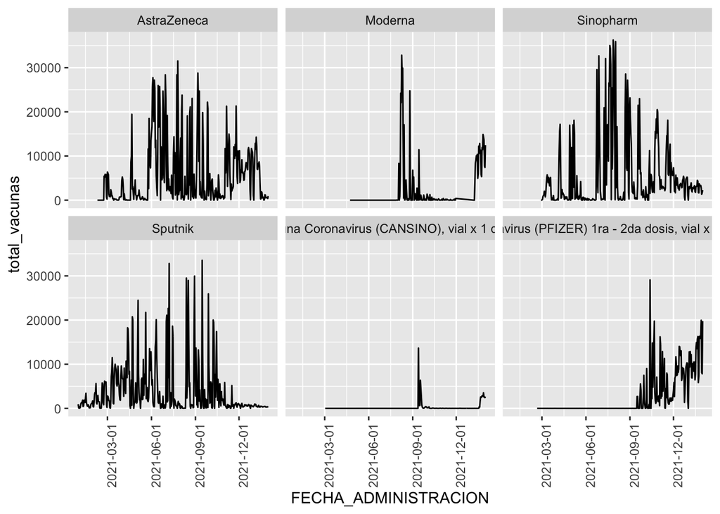

```r
ggplot(tipo_vacuna, aes(x = FECHA_ADMINISTRACION, y = total_vacunas))+
  geom_line(data =tipo_vacuna, aes(y = total_vacunas))+
  facet_wrap(~VACUNA)+
  scale_x_date(breaks = '3 month')+
  theme(axis.text.x = element_text(angle = 90))
```

## 8- Realizar un gráfico de barras que exprese la proporción de vacunas aplicadas agrupado por rango etario.

```r
rangos <- base_caba %>%
  group_by(GRUPO_ETARIO) %>%
  summarise(total = sum(total_vacunas), # total de vacunas aplicadas
            varones_n = sum(total_vacunas[GENERO == 'M']), # total aplicadas a varones
            mujeres_n = sum(total_vacunas[GENERO =='F']), # total aplicadas a mujeres
            varones = varones_n / total * 100, # proporcion a varones
            mujeres = mujeres_n / total * 100) %>%  # proporcion a mujeres
  mutate(varones = as.integer(varones), # convertirmos el valor en entero
         mujeres = as.integer(mujeres)) %>%  # idem
  select(GRUPO_ETARIO, varones, mujeres) %>% # seleccionamos las columnas que nos interesan
  pivot_longer(., cols = 2:3, names_to = 'GENERO', values_to = 'Porcentaje') # Pasamos el género como fila

head(rangos)
```

```
## # A tibble: 6 × 3
##   GRUPO_ETARIO GENERO  Porcentaje
##   <chr>        <chr>        <int>
## 1 30 o menos   varones         48
## 2 30 o menos   mujeres         51
## 3 31 a 40      varones         47
## 4 31 a 40      mujeres         52
## 5 41 a 50      varones         47
## 6 41 a 50      mujeres         52
```

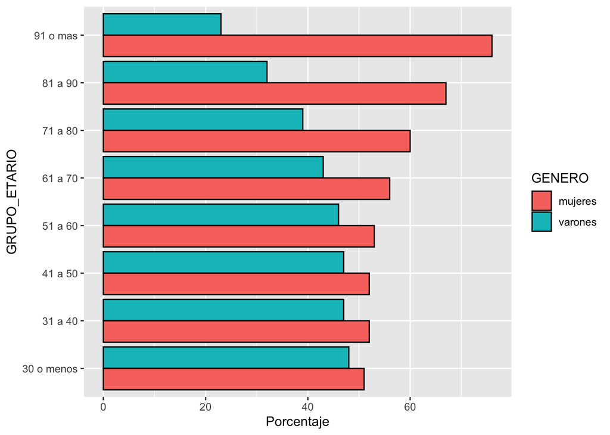

```r
ggplot(rangos) +
  aes(x = GRUPO_ETARIO, y = Porcentaje , fill = GENERO)+
  geom_col( color = 'black',
           position = position_dodge())+
  coord_flip()
```